# ML- Assignment 4 Problem 2

Problem2— Predicting Bike Sharing Demand For this problem, you will be working with the bike sharing demand dataset from Kaggle: https://www.kaggle.com/competitions/bike-sharing-demand/data?select=train.csv . The dataset is comprised of hourly bike rental data spanning two years (2011-2012). The goal is to predict the totalcount of bike rentals based on features such as date, temperature, whether it is holiday, working day etc. This data is a time-series data because the observations are in a sequence and there is a temporal order between them. However for the sake of this assignment, let’s assume that the observations are independent and identically distributed (i.i.d). click on the link above and read the data description on Kaggle. Then download bike-data.csv file from canvas

Let’s first load the dataset.

```r
bike = read.csv("C:/Users/CSC/Downloads/bike.csv")
bike
```

| datetime | season | holiday | workingday | weather | temp | atemp | humidity | windspeed | casual | registered | count |
| --- | --- | --- | --- | --- | --- | --- | --- | --- | --- | --- | --- |
| 2011-01-01 00:00:00 | 1 | 0 | 0 | 1 | 9.84 | 14.395 | 81 | 0.0000 | 3 | 13 | 16 |
| 2011-01-01 01:00:00 | 1 | 0 | 0 | 1 | 9.02 | 13.635 | 80 | 0.0000 | 8 | 32 | 40 |
| 2011-01-01 02:00:00 | 1 | 0 | 0 | 1 | 9.02 | 13.635 | 80 | 0.0000 | 5 | 27 | 32 |
| 2011-01-01 03:00:00 | 1 | 0 | 0 | 1 | 9.84 | 14.395 | 75 | 0.0000 | 3 | 10 | 13 |
| 2011-01-01 04:00:00 | 1 | 0 | 0 | 1 | 9.84 | 14.395 | 75 | 0.0000 | 0 | 1 | 1 |
| 2011-01-01 05:00:00 | 1 | 0 | 0 | 2 | 9.84 | 12.880 | 75 | 6.0032 | 0 | 1 | 1 |
| 2011-01-01 06:00:00 | 1 | 0 | 0 | 1 | 9.02 | 13.635 | 80 | 0.0000 | 2 | 0 | 2 |
| 2011-01-01 07:00:00 | 1 | 0 | 0 | 1 | 8.20 | 12.880 | 86 | 0.0000 | 1 | 2 | 3 |
| 2011-01-01 08:00:00 | 1 | 0 | 0 | 1 | 9.84 | 14.395 | 75 | 0.0000 | 1 | 7 | 8 |
| 2011-01-01 09:00:00 | 1 | 0 | 0 | 1 | 13.12 | 17.425 | 76 | 0.0000 | 8 | 6 | 14 |

[output cut: 990 more lines]

The Data Description from Kaggle:

datetime - hourly date + timestamp  
season - 1 = spring, 2 = summer, 3 = fall, 4 = winter holiday - whether the day is considered a holiday workingday - whether the day is neither a weekend nor holiday weather - 1: Clear, Few clouds, Partly cloudy, Partly cloudy 2: Mist + Cloudy, Mist + Broken clouds, Mist + Few clouds, Mist 3: Light Snow, Light Rain + Thunderstorm + Scattered clouds, Light Rain + Scattered clouds 4: Heavy Rain + Ice Pallets + Thunderstorm + Mist, Snow + Fog temp - temperature in Celsius atemp - “feels like” temperature in Celsius humidity - relative humidity windspeed - wind speed casual - number of non-registered user rentals initiated registered - number of registered user rentals initiated count - number of total rentals

1. (2p) explore the overall structure of the dataset using the str() function. Get a summary statistics of each variable. Answer the following questions: o How many observations do you have in the data? o What is the type of each variable? Categorical ( nominal or ordinal) or continuous? o Is there any missing value? o Draw the histogram of count. Interpret what you see in the histogram

```r
# Let's explore the dataset:
obs = nrow(bike)
print(paste("The number of observations are:",obs))
```

```
[1] "The number of observations are: 10886"
```

```r
str(bike)
```

```
'data.frame':   10886 obs. of  12 variables:
 $ datetime  : chr  "2011-01-01 00:00:00" "2011-01-01 01:00:00" "2011-01-01 02:00:00" "2011-01-01 03:00:00" ...
 $ season    : int  1 1 1 1 1 1 1 1 1 1 ...
 $ holiday   : int  0 0 0 0 0 0 0 0 0 0 ...
 $ workingday: int  0 0 0 0 0 0 0 0 0 0 ...
 $ weather   : int  1 1 1 1 1 2 1 1 1 1 ...
 $ temp      : num  9.84 9.02 9.02 9.84 9.84 ...
 $ atemp     : num  14.4 13.6 13.6 14.4 14.4 ...
 $ humidity  : int  81 80 80 75 75 75 80 86 75 76 ...
 $ windspeed : num  0 0 0 0 0 ...
 $ casual    : int  3 8 5 3 0 0 2 1 1 8 ...
 $ registered: int  13 32 27 10 1 1 0 2 7 6 ...
 $ count     : int  16 40 32 13 1 1 2 3 8 14 ...
```

```r
summary(bike)
```

```
   datetime             season         holiday          workingday        weather           temp
 Length:10886       Min.   :1.000   Min.   :0.00000   Min.   :0.0000   Min.   :1.000   Min.   : 0.82
 Class :character   1st Qu.:2.000   1st Qu.:0.00000   1st Qu.:0.0000   1st Qu.:1.000   1st Qu.:13.94
 Mode  :character   Median :3.000   Median :0.00000   Median :1.0000   Median :1.000   Median :20.50
                    Mean   :2.507   Mean   :0.02857   Mean   :0.6809   Mean   :1.418   Mean   :20.23
                    3rd Qu.:4.000   3rd Qu.:0.00000   3rd Qu.:1.0000   3rd Qu.:2.000   3rd Qu.:26.24
                    Max.   :4.000   Max.   :1.00000   Max.   :1.0000   Max.   :4.000   Max.   :41.00
     atemp          humidity        windspeed          casual         registered        count
 Min.   : 0.76   Min.   :  0.00   Min.   : 0.000   Min.   :  0.00   Min.   :  0.0   Min.   :  1.0
 1st Qu.:16.66   1st Qu.: 47.00   1st Qu.: 7.002   1st Qu.:  4.00   1st Qu.: 36.0   1st Qu.: 42.0
 Median :24.24   Median : 62.00   Median :12.998   Median : 17.00   Median :118.0   Median :145.0
 Mean   :23.66   Mean   : 61.89   Mean   :12.799   Mean   : 36.02   Mean   :155.6   Mean   :191.6
 3rd Qu.:31.06   3rd Qu.: 77.00   3rd Qu.:16.998   3rd Qu.: 49.00   3rd Qu.:222.0   3rd Qu.:284.0
 Max.   :45.45   Max.   :100.00   Max.   :56.997   Max.   :367.00   Max.   :886.0   Max.   :977.0
```

According to the summary and dataset description:

The categorical variables are: 1. datetime 2. season (because there are four diff season categories and in order; therefore it’s an ordinal categorical feauture) 3. holiday (As they have binary values for whether there is a holiday or not; no specific order therefore it’s nominal) 4. workingday (nominal) 5. weather (there are four different types of weather categories provided without any order; therefore it’s nominal)

The continuous variables are: 1. temp 2. atemp 3. humidity 4. windspeed 5. casual 6. registered

The target predicted value is: 1. count

```r
na_values = sum(is.na(bike))
print(paste("The null values are:", na_values))
```

```
[1] "The null values are: 0"
```

We can see, there are no null values. Great !

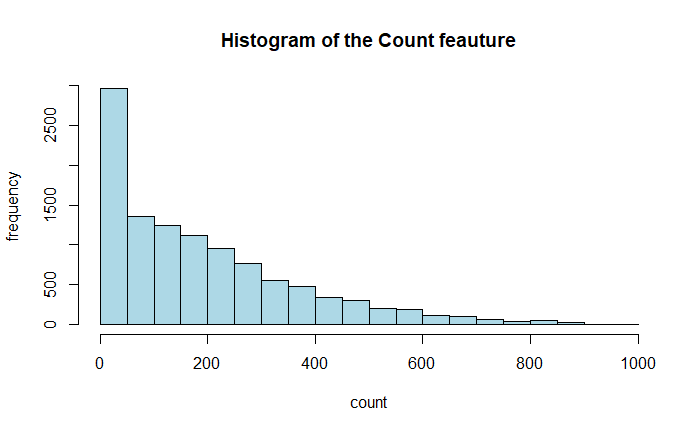

```r
hist(bike$count,
     col="lightblue",
     main = "Histogram of the Count feauture",
     xlab = "count",
     ylab = "frequency")
```

The interpretation of this graph suggests that as the values keeps on increasing, thier count decreases. It’s a right skewed data.

Let’s perform Feauture Engineering 2. Remove the “registered” and “casual” variables. These are the count of registered and casual users and together they can perfectly predict “count” so we are removing them from the model and predict count from the other features.

```r
bike = subset(bike, select = -c(registered, casual))
bike
```

|  | datetime | season | holiday | workingday | weather | temp | atemp | humidity | windspeed | count |
| --- | --- | --- | --- | --- | --- | --- | --- | --- | --- | --- |
| 1 | 2011-01-01 00:00:00 | 1 | 0 | 0 | 1 | 9.84 | 14.395 | 81 | 0.0000 | 16 |
| 2 | 2011-01-01 01:00:00 | 1 | 0 | 0 | 1 | 9.02 | 13.635 | 80 | 0.0000 | 40 |
| 3 | 2011-01-01 02:00:00 | 1 | 0 | 0 | 1 | 9.02 | 13.635 | 80 | 0.0000 | 32 |
| 4 | 2011-01-01 03:00:00 | 1 | 0 | 0 | 1 | 9.84 | 14.395 | 75 | 0.0000 | 13 |
| 5 | 2011-01-01 04:00:00 | 1 | 0 | 0 | 1 | 9.84 | 14.395 | 75 | 0.0000 | 1 |
| 6 | 2011-01-01 05:00:00 | 1 | 0 | 0 | 2 | 9.84 | 12.880 | 75 | 6.0032 | 1 |
| 7 | 2011-01-01 06:00:00 | 1 | 0 | 0 | 1 | 9.02 | 13.635 | 80 | 0.0000 | 2 |
| 8 | 2011-01-01 07:00:00 | 1 | 0 | 0 | 1 | 8.20 | 12.880 | 86 | 0.0000 | 3 |
| 9 | 2011-01-01 08:00:00 | 1 | 0 | 0 | 1 | 9.84 | 14.395 | 75 | 0.0000 | 8 |
| 10 | 2011-01-01 09:00:00 | 1 | 0 | 0 | 1 | 13.12 | 17.425 | 76 | 0.0000 | 14 |

[output cut: 990 more lines]

3. (1p) The count variable is severely right-skewed. A skewed target variable can make a machine learning model biased. For instance, in this case lower counts are more frequent in the training data compared to higher counts . Therefore, a machine learning model trained on this data is less likely to successfully predict higher counts. There are different ways we can transform a right-skewed variable to a more bell-shape distribution. Common transformations for a right-skewed data includes log, square-root and cube-root transformations. We are going to use square root transformation here to make the distribution of count more bell-shaped. Set the count variable in your dataframe equal to square root of count and plot its distribution again.

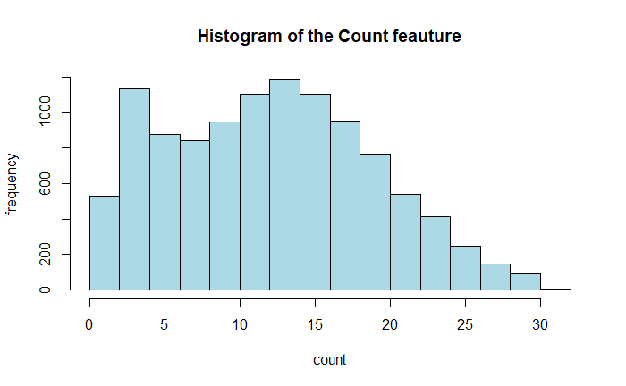

```r
# Transforming the count variable through square root method to distribute it more bell-shaped.
bike$count = sqrt(bike$count)
hist(bike$count,
     col="lightblue",
     main = "Histogram of the Count feauture",
     xlab = "count",
     ylab = "frequency")
```

Now, this looks more bell-shaped.

4. (2 pt) Variable datetime is not useful in its current form. Convert this variable to “day of month”, “year”, “day of week”, ”month” and “hour” variables. You can use as.POSIXlt function to extract those features from datetime. Please see this reference for an example. Remove the original datetime variable after conversion

```r
# Extracting from datetime variable and creating features like day_of_month, year, day_of_week, month, hour variables

bike$datetime = as.POSIXlt(bike$datetime)

bike$day_of_month = bike$datetime$mday
bike$year = bike$datetime$year + 1900
bike$day_of_week = bike$datetime$wday
bike$month = bike$datetime$mon + 1
bike$hour = bike$datetime$hour
```

```r
# Let's remove the datetime variable after extracting

bike = subset(bike, select = -c(datetime))
bike
```

|  | season | holiday | workingday | weather | temp | atemp | humidity | windspeed | count | day_of_month | year | day_of_week | month | hour |
| --- | --- | --- | --- | --- | --- | --- | --- | --- | --- | --- | --- | --- | --- | --- |
| 1 | 1 | 0 | 0 | 1 | 9.84 | 14.395 | 81 | 0.0000 | 4.000000 | 1 | 2011 | 6 | 1 | 0 |
| 2 | 1 | 0 | 0 | 1 | 9.02 | 13.635 | 80 | 0.0000 | 6.324555 | 1 | 2011 | 6 | 1 | 1 |
| 3 | 1 | 0 | 0 | 1 | 9.02 | 13.635 | 80 | 0.0000 | 5.656854 | 1 | 2011 | 6 | 1 | 2 |
| 4 | 1 | 0 | 0 | 1 | 9.84 | 14.395 | 75 | 0.0000 | 3.605551 | 1 | 2011 | 6 | 1 | 3 |
| 5 | 1 | 0 | 0 | 1 | 9.84 | 14.395 | 75 | 0.0000 | 1.000000 | 1 | 2011 | 6 | 1 | 4 |
| 6 | 1 | 0 | 0 | 2 | 9.84 | 12.880 | 75 | 6.0032 | 1.000000 | 1 | 2011 | 6 | 1 | 5 |
| 7 | 1 | 0 | 0 | 1 | 9.02 | 13.635 | 80 | 0.0000 | 1.414214 | 1 | 2011 | 6 | 1 | 6 |
| 8 | 1 | 0 | 0 | 1 | 8.20 | 12.880 | 86 | 0.0000 | 1.732051 | 1 | 2011 | 6 | 1 | 7 |
| 9 | 1 | 0 | 0 | 1 | 9.84 | 14.395 | 75 | 0.0000 | 2.828427 | 1 | 2011 | 6 | 1 | 8 |
| 10 | 1 | 0 | 0 | 1 | 13.12 | 17.425 | 76 | 0.0000 | 3.741657 | 1 | 2011 | 6 | 1 | 9 |

[output cut: 990 more lines]

5. (3pt) Variables “month”, “day of week”, “hour”, and “season” are categorical but they are also circular. This means these variables are periodic in nature. If we represent a circular variable like “month” with numeric indices 0-11 we are implying that the distance between month 10 (November) and month 11 (December) is much lower than the distance between month 11(December) and month 0 (January) which is not correct. At the other hand if we one-hot-encode the “month” variable we are ignoring the chronological ordering between month values and assume that the distance between every two months is equal. A better way to represent these variables is to map each value into a point in a circle where the lowest value appears next to the largest value in the circle. For instance, we can transform the “month” variable by creating “x” and “y” coordinates of the point in such circle using sin and cosine transformations as follows: Convert variables “month”, “day of week”, “hour”, and “season” to their x and y coordinates using sin and cosine transformation as explained above. Make sure to remove the original “month”, “day of week”, “hour”, and “season” variables after transformation. Note: The “day of month” variable is also technically circular but this dataset only contains days 1-19 therefore we can just convert “day” variable to numeric indices using “as.numeric” function.

```r
summary(bike)
```

```
     season         holiday          workingday        weather           temp           atemp
 Min.   :1.000   Min.   :0.00000   Min.   :0.0000   Min.   :1.000   Min.   : 0.82   Min.   : 0.76
 1st Qu.:2.000   1st Qu.:0.00000   1st Qu.:0.0000   1st Qu.:1.000   1st Qu.:13.94   1st Qu.:16.66
 Median :3.000   Median :0.00000   Median :1.0000   Median :1.000   Median :20.50   Median :24.24
 Mean   :2.507   Mean   :0.02857   Mean   :0.6809   Mean   :1.418   Mean   :20.23   Mean   :23.66
 3rd Qu.:4.000   3rd Qu.:0.00000   3rd Qu.:1.0000   3rd Qu.:2.000   3rd Qu.:26.24   3rd Qu.:31.06
 Max.   :4.000   Max.   :1.00000   Max.   :1.0000   Max.   :4.000   Max.   :41.00   Max.   :45.45
    humidity        windspeed          count         day_of_month         year       day_of_week
 Min.   :  0.00   Min.   : 0.000   Min.   : 1.000   Min.   : 1.000   Min.   :2011   Min.   :0.000
 1st Qu.: 47.00   1st Qu.: 7.002   1st Qu.: 6.481   1st Qu.: 5.000   1st Qu.:2011   1st Qu.:1.000
 Median : 62.00   Median :12.998   Median :12.042   Median :10.000   Median :2012   Median :3.000
 Mean   : 61.89   Mean   :12.799   Mean   :12.106   Mean   : 9.993   Mean   :2012   Mean   :2.999
 3rd Qu.: 77.00   3rd Qu.:16.998   3rd Qu.:16.852   3rd Qu.:15.000   3rd Qu.:2012   3rd Qu.:5.000
 Max.   :100.00   Max.   :56.997   Max.   :31.257   Max.   :19.000   Max.   :2012   Max.   :6.000
     month             hour
 Min.   : 1.000   Min.   : 0.00
 1st Qu.: 4.000   1st Qu.: 6.00
 Median : 7.000   Median :12.00
 Mean   : 6.521   Mean   :11.54
 3rd Qu.:10.000   3rd Qu.:18.00
 Max.   :12.000   Max.   :23.00
```

```r
# let's define the maximum values of these variable using the summary function beforehand:
max_mon = 12
max_day_of_week = 6
max_hour = 23
max_season = 4
```

```r
# Converting month, day_of_week, hour, season into x and y coordinates:

bike$x_month = cos(2 * pi * bike$month / max_mon)
bike$y_month = sin(2 * pi * bike$month / max_mon)

bike$x_day_of_week = cos(2 * pi * bike$day_of_week / max_day_of_week)
bike$y_day_of_week = sin(2 * pi * bike$day_of_week / max_day_of_week)

bike$x_hour = cos(2 * pi * bike$hour / max_hour)
bike$y_hour = sin(2 * pi * bike$hour / max_hour)

bike$x_season = cos(2 * pi * bike$season / max_season)
bike$y_season = sin(2 * pi * bike$season / max_season)

# Let's remove the old values

bike = subset(bike, select = -c(month, day_of_week, hour, season))

print(bike)
```

|  | holiday | workingday | weather | temp | atemp | humidity | windspeed | count | day_of_month | year | x_month | y_month | x_day_of_week | y_day_of_week | x_hour | y_hour | x_season | y_season |
| --- | --- | --- | --- | --- | --- | --- | --- | --- | --- | --- | --- | --- | --- | --- | --- | --- | --- | --- |
| 1 | 0 | 0 | 1 | 9.84 | 14.395 | 81 | 0.0000 | 4.000000 | 1 | 2011 | 8.660254e-01 | 0.5000000 | 1.0 | -2.449213e-16 | 1.00000000 | 0.000000e+00 | 6.123032e-17 | 1 |
| 2 | 0 | 0 | 1 | 9.02 | 13.635 | 80 | 0.0000 | 6.324555 | 1 | 2011 | 8.660254e-01 | 0.5000000 | 1.0 | -2.449213e-16 | 0.96291729 | 2.697968e-01 | 6.123032e-17 | 1 |
| 3 | 0 | 0 | 1 | 9.02 | 13.635 | 80 | 0.0000 | 5.656854 | 1 | 2011 | 8.660254e-01 | 0.5000000 | 1.0 | -2.449213e-16 | 0.85441940 | 5.195840e-01 | 6.123032e-17 | 1 |
| 4 | 0 | 0 | 1 | 9.84 | 14.395 | 75 | 0.0000 | 3.605551 | 1 | 2011 | 8.660254e-01 | 0.5000000 | 1.0 | -2.449213e-16 | 0.68255314 | 7.308360e-01 | 6.123032e-17 | 1 |
| 5 | 0 | 0 | 1 | 9.84 | 14.395 | 75 | 0.0000 | 1.000000 | 1 | 2011 | 8.660254e-01 | 0.5000000 | 1.0 | -2.449213e-16 | 0.46006504 | 8.878852e-01 | 6.123032e-17 | 1 |
| 6 | 0 | 0 | 2 | 9.84 | 12.880 | 75 | 6.0032 | 1.000000 | 1 | 2011 | 8.660254e-01 | 0.5000000 | 1.0 | -2.449213e-16 | 0.20345601 | 9.790841e-01 | 6.123032e-17 | 1 |
| 7 | 0 | 0 | 1 | 9.02 | 13.635 | 80 | 0.0000 | 1.414214 | 1 | 2011 | 8.660254e-01 | 0.5000000 | 1.0 | -2.449213e-16 | -0.06824241 | 9.976688e-01 | 6.123032e-17 | 1 |
| 8 | 0 | 0 | 1 | 8.20 | 12.880 | 86 | 0.0000 | 1.732051 | 1 | 2011 | 8.660254e-01 | 0.5000000 | 1.0 | -2.449213e-16 | -0.33487961 | 9.422609e-01 | 6.123032e-17 | 1 |
| 9 | 0 | 0 | 1 | 9.84 | 14.395 | 75 | 0.0000 | 2.828427 | 1 | 2011 | 8.660254e-01 | 0.5000000 | 1.0 | -2.449213e-16 | -0.57668032 | 8.169699e-01 | 6.123032e-17 | 1 |
| 10 | 0 | 0 | 1 | 13.12 | 17.425 | 76 | 0.0000 | 3.741657 | 1 | 2011 | 8.660254e-01 | 0.5000000 | 1.0 | -2.449213e-16 | -0.77571129 | 6.310879e-01 | 6.123032e-17 | 1 |

[output cut: 990 more lines]

```r
NA
```

```r
# Converting day_of_month to numeric

bike$day_of_month = as.numeric(bike$day_of_month)
print(bike)
```

|  | holiday | workingday | weather | temp | atemp | humidity | windspeed | count | day_of_month | year | x_month | y_month | x_day_of_week | y_day_of_week | x_hour | y_hour | x_season | y_season |
| --- | --- | --- | --- | --- | --- | --- | --- | --- | --- | --- | --- | --- | --- | --- | --- | --- | --- | --- |
| 1 | 0 | 0 | 1 | 9.84 | 14.395 | 81 | 0.0000 | 4.000000 | 1 | 2011 | 8.660254e-01 | 0.5000000 | 1.0 | -2.449213e-16 | 1.00000000 | 0.000000e+00 | 6.123032e-17 | 1 |
| 2 | 0 | 0 | 1 | 9.02 | 13.635 | 80 | 0.0000 | 6.324555 | 1 | 2011 | 8.660254e-01 | 0.5000000 | 1.0 | -2.449213e-16 | 0.96291729 | 2.697968e-01 | 6.123032e-17 | 1 |
| 3 | 0 | 0 | 1 | 9.02 | 13.635 | 80 | 0.0000 | 5.656854 | 1 | 2011 | 8.660254e-01 | 0.5000000 | 1.0 | -2.449213e-16 | 0.85441940 | 5.195840e-01 | 6.123032e-17 | 1 |
| 4 | 0 | 0 | 1 | 9.84 | 14.395 | 75 | 0.0000 | 3.605551 | 1 | 2011 | 8.660254e-01 | 0.5000000 | 1.0 | -2.449213e-16 | 0.68255314 | 7.308360e-01 | 6.123032e-17 | 1 |
| 5 | 0 | 0 | 1 | 9.84 | 14.395 | 75 | 0.0000 | 1.000000 | 1 | 2011 | 8.660254e-01 | 0.5000000 | 1.0 | -2.449213e-16 | 0.46006504 | 8.878852e-01 | 6.123032e-17 | 1 |
| 6 | 0 | 0 | 2 | 9.84 | 12.880 | 75 | 6.0032 | 1.000000 | 1 | 2011 | 8.660254e-01 | 0.5000000 | 1.0 | -2.449213e-16 | 0.20345601 | 9.790841e-01 | 6.123032e-17 | 1 |
| 7 | 0 | 0 | 1 | 9.02 | 13.635 | 80 | 0.0000 | 1.414214 | 1 | 2011 | 8.660254e-01 | 0.5000000 | 1.0 | -2.449213e-16 | -0.06824241 | 9.976688e-01 | 6.123032e-17 | 1 |
| 8 | 0 | 0 | 1 | 8.20 | 12.880 | 86 | 0.0000 | 1.732051 | 1 | 2011 | 8.660254e-01 | 0.5000000 | 1.0 | -2.449213e-16 | -0.33487961 | 9.422609e-01 | 6.123032e-17 | 1 |
| 9 | 0 | 0 | 1 | 9.84 | 14.395 | 75 | 0.0000 | 2.828427 | 1 | 2011 | 8.660254e-01 | 0.5000000 | 1.0 | -2.449213e-16 | -0.57668032 | 8.169699e-01 | 6.123032e-17 | 1 |
| 10 | 0 | 0 | 1 | 13.12 | 17.425 | 76 | 0.0000 | 3.741657 | 1 | 2011 | 8.660254e-01 | 0.5000000 | 1.0 | -2.449213e-16 | -0.77571129 | 6.310879e-01 | 6.123032e-17 | 1 |

[output cut: 990 more lines]

6. (2pt) Neural networks do not accept categorical variables and we must encode the categorical variables before training the network. One-hot-encode all the categorical variables in your dataset. Note: binary variables such as “holiday” and “workingday” are already converted to 0-1 and don’t need to be one-hot-encoded.

Categorical variables: 1. season 2. weather

```r
# Let's check which all features are required to be one-hot encoded:
summary(bike)
```

```
    holiday          workingday        weather           temp           atemp          humidity
 Min.   :0.00000   Min.   :0.0000   Min.   :1.000   Min.   : 0.82   Min.   : 0.76   Min.   :  0.00
 1st Qu.:0.00000   1st Qu.:0.0000   1st Qu.:1.000   1st Qu.:13.94   1st Qu.:16.66   1st Qu.: 47.00
 Median :0.00000   Median :1.0000   Median :1.000   Median :20.50   Median :24.24   Median : 62.00
 Mean   :0.02857   Mean   :0.6809   Mean   :1.418   Mean   :20.23   Mean   :23.66   Mean   : 61.89
 3rd Qu.:0.00000   3rd Qu.:1.0000   3rd Qu.:2.000   3rd Qu.:26.24   3rd Qu.:31.06   3rd Qu.: 77.00
 Max.   :1.00000   Max.   :1.0000   Max.   :4.000   Max.   :41.00   Max.   :45.45   Max.   :100.00
   windspeed          count         day_of_month         year         x_month            y_month
 Min.   : 0.000   Min.   : 1.000   Min.   : 1.000   Min.   :2011   Min.   :-1.00000   Min.   :-1.000000
 1st Qu.: 7.002   1st Qu.: 6.481   1st Qu.: 5.000   1st Qu.:2011   1st Qu.:-0.86603   1st Qu.:-0.866025
 Median :12.998   Median :12.042   Median :10.000   Median :2012   Median : 0.00000   Median : 0.000000
 Mean   :12.799   Mean   :12.106   Mean   : 9.993   Mean   :2012   Mean   :-0.00272   Mean   :-0.003009
 3rd Qu.:16.998   3rd Qu.:16.852   3rd Qu.:15.000   3rd Qu.:2012   3rd Qu.: 0.50000   3rd Qu.: 0.500000
 Max.   :56.997   Max.   :31.257   Max.   :19.000   Max.   :2012   Max.   : 1.00000   Max.   : 1.000000
 x_day_of_week     y_day_of_week            x_hour             y_hour             x_season
 Min.   :-1.0000   Min.   :-0.8660254   Min.   :-0.99069   Min.   :-0.997669   Min.   :-1.00e+00
 1st Qu.:-0.5000   1st Qu.:-0.8660254   1st Qu.:-0.77571   1st Qu.:-0.730836   1st Qu.:-1.00e+00
 Median : 0.5000   Median : 0.0000000   Median :-0.06824   Median : 0.000000   Median : 0.00e+00
 Mean   : 0.1475   Mean   : 0.0006364   Mean   : 0.03922   Mean   :-0.003838   Mean   : 9.19e-05
 3rd Qu.: 1.0000   3rd Qu.: 0.8660254   3rd Qu.: 0.85442   3rd Qu.: 0.631088   3rd Qu.: 1.00e+00
 Max.   : 1.0000   Max.   : 0.8660254   Max.   : 1.00000   Max.   : 0.997669   Max.   : 1.00e+00
    y_season
 Min.   :-1.000000
 1st Qu.:-1.000000
 Median : 0.000000
 Mean   :-0.004318
 3rd Qu.: 0.000000
 Max.   : 1.000000
```

The “weather” feature is supposed to be one-hot encoded.

```r
#install.packages('data.table')
install.packages("ggplot2")
```

```r
library(caret)
library(ggplot2)
library(lattice)
library(data.table)
library(mltools)
```

```r
# First lets convert into factors
bike_encoded = bike
bike_encoded$weather = as.factor(bike_encoded$weather)
dt = as.data.table(bike_encoded)
```

```r
bike_encoded = as.data.frame(one_hot(dt, cols = "weather", sparsifyNAs = FALSE, naCols = FALSE, dropCols = TRUE,
                                     dropUnusedLevels = TRUE))
```

```r
library(dplyr)
bike = bike %>%mutate_if(is.integer, as.numeric)

str(bike)
```

```
'data.frame':   10886 obs. of  18 variables:
 $ holiday      : num  0 0 0 0 0 0 0 0 0 0 ...
 $ workingday   : num  0 0 0 0 0 0 0 0 0 0 ...
 $ weather      : num  1 1 1 1 1 2 1 1 1 1 ...
 $ temp         : num  9.84 9.02 9.02 9.84 9.84 ...
 $ atemp        : num  14.4 13.6 13.6 14.4 14.4 ...
 $ humidity     : num  81 80 80 75 75 75 80 86 75 76 ...
 $ windspeed    : num  0 0 0 0 0 ...
 $ count        : num  4 6.32 5.66 3.61 1 ...
 $ day_of_month : num  1 1 1 1 1 1 1 1 1 1 ...
 $ year         : num  2011 2011 2011 2011 2011 ...
 $ x_month      : num  0.866 0.866 0.866 0.866 0.866 ...
 $ y_month      : num  0.5 0.5 0.5 0.5 0.5 0.5 0.5 0.5 0.5 0.5 ...
 $ x_day_of_week: num  1 1 1 1 1 1 1 1 1 1 ...
 $ y_day_of_week: num  -2.45e-16 -2.45e-16 -2.45e-16 -2.45e-16 -2.45e-16 ...
 $ x_hour       : num  1 0.963 0.854 0.683 0.46 ...
 $ y_hour       : num  0 0.27 0.52 0.731 0.888 ...
 $ x_season     : num  6.12e-17 6.12e-17 6.12e-17 6.12e-17 6.12e-17 ...
 $ y_season     : num  1 1 1 1 1 1 1 1 1 1 ...
```

7. Use set.seed(1) to set the random seed so I can reproduce your results

```r
set.seed(1)
```

8. Use Caret’s “createDataPartition” method as follows to partition the dataset into bikes_train, and bikes_test (use 90% for training and 10% for testing)

```r
library(ggplot2)
library(lattice)
library(caret)
inTrain = createDataPartition(bike$count,p =0.9, list = FALSE)
bike_train = bike[inTrain,]
bike_test = bike[-inTrain,]
```

9. (1pt) Set.seed(1) and further divide the bikes_train data into 90% training and 10% validation using Caret’s “CreateDataPartition” function.

```r
set.seed(1)
inTrainValidation = createDataPartition(bike_train$count,p =0.9, list = FALSE)
bike_training = bike_train[inTrainValidation,]
bike_validation = bike_train[-inTrainValidation,]
```

10. ( 2 pt) Scale the numeric attributes in the training data (except for the outcome variable, “count”). Use the column means and column standard deviations from the training data to scale both the validation and test data (please refer to slide 81, lecture 9). Note: You should NOT scale the dummy variables you created in step 6.

```r
summary(bike_train)
```

```
    holiday          workingday        weather           temp           atemp          humidity
 Min.   :0.00000   Min.   :0.0000   Min.   :1.000   Min.   : 0.82   Min.   : 0.76   Min.   :  0.00
 1st Qu.:0.00000   1st Qu.:0.0000   1st Qu.:1.000   1st Qu.:13.94   1st Qu.:16.66   1st Qu.: 47.00
 Median :0.00000   Median :1.0000   Median :1.000   Median :20.50   Median :24.24   Median : 62.00
 Mean   :0.02817   Mean   :0.6804   Mean   :1.418   Mean   :20.29   Mean   :23.72   Mean   : 61.86
 3rd Qu.:0.00000   3rd Qu.:1.0000   3rd Qu.:2.000   3rd Qu.:26.24   3rd Qu.:31.06   3rd Qu.: 77.00
 Max.   :1.00000   Max.   :1.0000   Max.   :3.000   Max.   :41.00   Max.   :45.45   Max.   :100.00
   windspeed          count         day_of_month         year         x_month             y_month
 Min.   : 0.000   Min.   : 1.000   Min.   : 1.000   Min.   :2011   Min.   :-1.000000   Min.   :-1.000000
 1st Qu.: 7.002   1st Qu.: 6.481   1st Qu.: 5.000   1st Qu.:2011   1st Qu.:-0.866025   1st Qu.:-0.866025
 Median :12.998   Median :12.042   Median :10.000   Median :2012   Median : 0.000000   Median : 0.000000
 Mean   :12.787   Mean   :12.094   Mean   : 9.964   Mean   :2012   Mean   :-0.007569   Mean   :-0.006234
 3rd Qu.:16.998   3rd Qu.:16.852   3rd Qu.:15.000   3rd Qu.:2012   3rd Qu.: 0.500000   3rd Qu.: 0.500000
 Max.   :56.997   Max.   :31.257   Max.   :19.000   Max.   :2012   Max.   : 1.000000   Max.   : 1.000000
 x_day_of_week     y_day_of_week           x_hour             y_hour             x_season
 Min.   :-1.0000   Min.   :-0.866025   Min.   :-0.99069   Min.   :-0.997669   Min.   :-1.000000
 1st Qu.:-0.5000   1st Qu.:-0.866025   1st Qu.:-0.77571   1st Qu.:-0.730836   1st Qu.:-1.000000
 Median : 0.5000   Median : 0.000000   Median :-0.06824   Median : 0.000000   Median : 0.000000
 Mean   : 0.1474   Mean   :-0.001237   Mean   : 0.03835   Mean   :-0.003828   Mean   :-0.003266
 3rd Qu.: 1.0000   3rd Qu.: 0.866025   3rd Qu.: 0.76849   3rd Qu.: 0.631088   3rd Qu.: 0.000000
 Max.   : 1.0000   Max.   : 0.866025   Max.   : 1.00000   Max.   : 0.997669   Max.   : 1.000000
    y_season
 Min.   :-1.0000
 1st Qu.:-1.0000
 Median : 0.0000
 Mean   :-0.0101
 3rd Qu.: 0.0000
 Max.   : 1.0000
```

```r
str(bike_training)
```

```
'data.frame':   8820 obs. of  18 variables:
 $ holiday      : num  0 0 0 0 0 0 0 0 0 0 ...
 $ workingday   : num  0 0 0 0 0 0 0 0 0 0 ...
 $ weather      : num  1 1 1 1 1 1 1 1 1 1 ...
 $ temp         : num  9.84 9.02 9.02 9.84 9.84 ...
 $ atemp        : num  14.4 13.6 13.6 14.4 14.4 ...
 $ humidity     : num  81 80 80 75 75 80 86 75 76 76 ...
 $ windspeed    : num  0 0 0 0 0 ...
 $ count        : num  4 6.32 5.66 3.61 1 ...
 $ day_of_month : num  1 1 1 1 1 1 1 1 1 1 ...
 $ year         : num  2011 2011 2011 2011 2011 ...
 $ x_month      : num  0.866 0.866 0.866 0.866 0.866 ...
 $ y_month      : num  0.5 0.5 0.5 0.5 0.5 0.5 0.5 0.5 0.5 0.5 ...
 $ x_day_of_week: num  1 1 1 1 1 1 1 1 1 1 ...
 $ y_day_of_week: num  -2.45e-16 -2.45e-16 -2.45e-16 -2.45e-16 -2.45e-16 ...
 $ x_hour       : num  1 0.963 0.854 0.683 0.46 ...
 $ y_hour       : num  0 0.27 0.52 0.731 0.888 ...
 $ x_season     : num  6.12e-17 6.12e-17 6.12e-17 6.12e-17 6.12e-17 ...
 $ y_season     : num  1 1 1 1 1 1 1 1 1 1 ...
```